# Practical Data Wrangling: Insights from 10,000 Rows of Dirty Cafe Sales Data

## So should we:

#### **a) Drop rows with missing values** **or** **b) Impute missing values** We can choose to impute the missing values in `item` with most frequent value.

```r
#Find most frequent

 most_frequent_item <- dataset_2 %>%
  filter(item != "") %>%
  count(item, sort = TRUE) %>%
  slice(1) %>%
  pull(item)

 print(most_frequent_item)
```

```
## [1] "Cake"
```

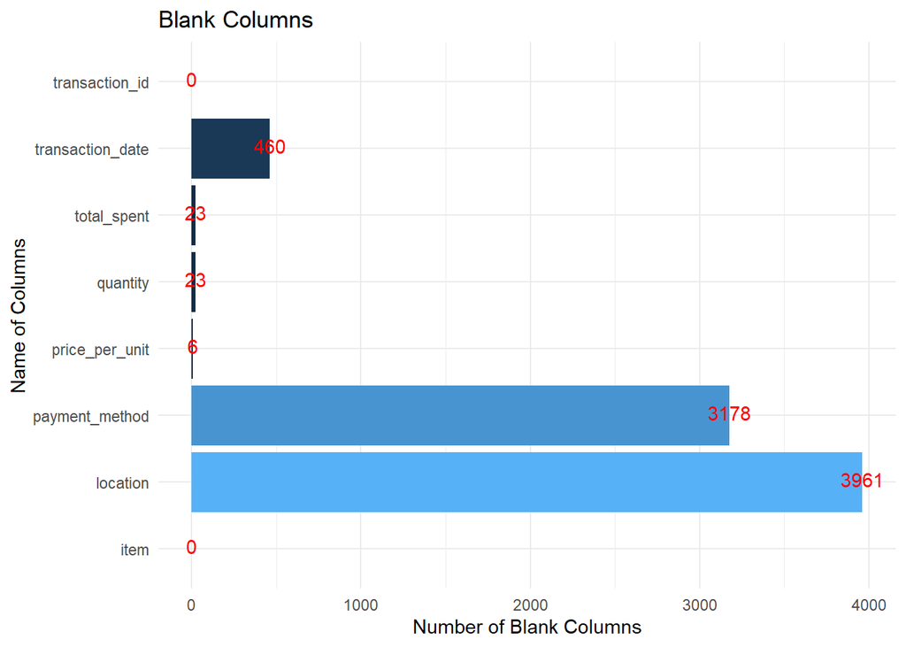

```r
# Replace NA values in the 'item' column with the most frequent value

dataset_impute <- dataset_2 %>%
  mutate(item = ifelse(is.na(item), "Cake", item
))

#Check NA in columns

na_columns <- data.frame(
  Column = names(dataset_impute),
  NA_count = colSums(is.na(dataset_impute))
)

#plot

ggplot(na_columns, aes(x = Column, y = NA_count, fill = (NA_count))) +
  geom_bar(stat = "identity") +
  geom_text(aes(label = NA_count), vjust = 0.3, color = "red") +
  coord_flip() +
  labs(
    title = "Blank Columns",
    x = "Name of Columns",
    y = "Number of Blank Columns",
    fill = "Columns"
  ) +
  theme_minimal() +
  theme(
    legend.position = "none"
  )
```

#### Which means we need to populate the NA in `price_per_unit`

```r
#Fetch price of Cake in price_to_refer

price_to_refer[price_to_refer$name_of_item == "Cake", ]
```

```
## # A tibble: 1 × 2
##   name_of_item price_of_item
##   <chr>                <dbl>
## 1 Cake                     3
```

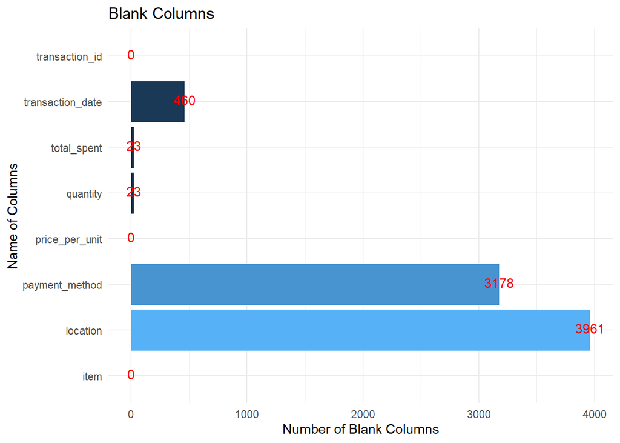

```r
# Replace NA values in the 'price_per_unit' column with 3

dataset_impute %<>%
  mutate(price_per_unit = ifelse(is.na(price_per_unit), 3, price_per_unit))

#Check NA in columns
na_columns <- data.frame(
  Column = names(dataset_impute),
  NA_count = colSums(is.na(dataset_impute))
)

#plot

ggplot(na_columns, aes(x = Column, y = NA_count, fill = (NA_count))) +
  geom_bar(stat = "identity") +
  geom_text(aes(label = NA_count), vjust = 0.3, color = "red") +
  coord_flip() +
  labs(
    title = "Blank Columns",
    x = "Name of Columns",
    y = "Number of Blank Columns",
    fill = "Columns"
  ) +
  theme_minimal() +
  theme(
    legend.position = "none"
  )
```

#### View the NA in `total_spent` and `quantity`

```r
view_na <- dataset_impute %>%
  filter(
    is.na(quantity)|
      is.na(total_spent)
  )

print(view_na)
```

```
##    transaction_id     item quantity price_per_unit total_spent payment_method
## 1     TXN_8562645    Salad       NA            5.0          NA           <NA>
## 2     TXN_3229409    Juice       NA            3.0          NA           Cash
## 3     TXN_2962976    Juice       NA            3.0          NA           <NA>
## 4     TXN_8696094 Sandwich       NA            4.0          NA           <NA>
## 5     TXN_3611851     Cake        4            3.0          NA    Credit Card
## 6     TXN_7524977     Cake        4            3.0          NA           <NA>
## 7     TXN_9188692     Cake       NA            3.0          NA    Credit Card
## 8     TXN_4565754 Smoothie       NA            4.0          NA Digital Wallet
## 9     TXN_6297232   Coffee       NA            2.0          NA           <NA>
## 10    TXN_3251829      Tea       NA            1.5          NA Digital Wallet
## 11    TXN_7376255     Cake       NA            3.0          25           <NA>
## 12    TXN_9646000     Cake        2            3.0          NA           <NA>
## 13    TXN_6470865   Coffee       NA            2.0          NA Digital Wallet
## 14    TXN_5884081   Cookie       NA            1.0          NA Digital Wallet
```

[output cut: 39 more lines]

#### It seems we can salvage a few NA

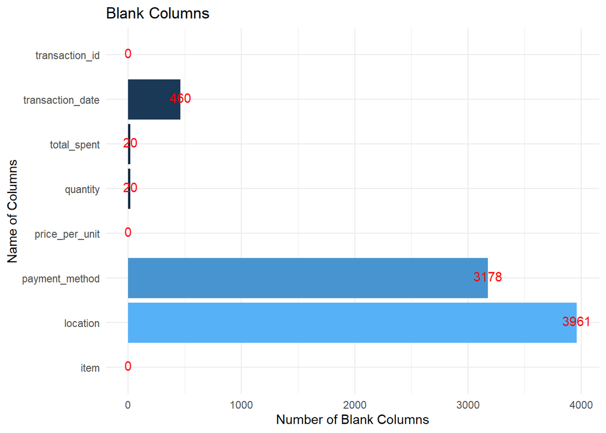

```r
#Fill NA in total_spent with the result of quantity * price_per_unit

dataset_impute %<>%
  mutate(
    total_spent = if_else(
      !is.na(quantity) & !is.na(price_per_unit),
      quantity * price_per_unit, total_spent
    )
  )

#Fill NA in quantity with the result of total_spent / price_per_unit
dataset_impute %<>%
  mutate(
    quantity = if_else(
      !is.na(total_spent) & !is.na(price_per_unit), total_spent/price_per_unit, quantity
    )
  )

#Check NA in columns
na_columns <- data.frame(
  Column = names(dataset_impute),
  NA_count = colSums(is.na(dataset_impute))
)

#plot

ggplot(na_columns, aes(x = Column, y = NA_count, fill = (NA_count))) +
  geom_bar(stat = "identity") +
  geom_text(aes(label = NA_count), vjust = 0.3, color = "red") +
  coord_flip() +
  labs(
    title = "Blank Columns",
    x = "Name of Columns",
    y = "Number of Blank Columns",
    fill = "Columns"
  ) +
  theme_minimal() +
  theme(
    legend.position = "none"
  )
```

#### **It seems we cannot impute further.** What follows next is dropping the 20 rows with NA.

```r
#Remove rows where why any column has NA
imputed_dataset <- dataset_impute %>%
  filter(!is.na(total_spent) &
           !is.na(quantity))

#Check NA in columns
na_columns <- data.frame(
  Column = names(imputed_dataset),
  NA_count = colSums(is.na(imputed_dataset))
)

print(na_columns)
```

```
##                            Column NA_count
## transaction_id     transaction_id        0
## item                         item        0
## quantity                 quantity        0
## price_per_unit     price_per_unit        0
## total_spent           total_spent        0
## payment_method     payment_method     3171
## location                 location     3955
## transaction_date transaction_date      460
```

#### Let’s see how may rows we are left with.

```r
skim(imputed_dataset)
```

Data summary

| Name | imputed_dataset |
| --- | --- |
| Number of rows | 9980 |
| Number of columns | 8 |
| _______________________ |  |
| Column type frequency: |  |
| character | 4 |
| Date | 1 |
| numeric | 3 |
| ________________________ |  |
| Group variables | None |

**Variable type: character**

| skim_variable | n_missing | complete_rate | min | max | empty | n_unique | whitespace |
| --- | --- | --- | --- | --- | --- | --- | --- |
| transaction_id | 0 | 1.00 | 11 | 11 | 0 | 9980 | 0 |
| item | 0 | 1.00 | 3 | 8 | 0 | 8 | 0 |
| payment_method | 3171 | 0.68 | 4 | 14 | 0 | 3 | 0 |
| location | 3955 | 0.60 | 8 | 8 | 0 | 2 | 0 |

**Variable type: Date**

| skim_variable | n_missing | complete_rate | min | max | median | n_unique |
| --- | --- | --- | --- | --- | --- | --- |
| transaction_date | 460 | 0.95 | 2023-01-01 | 2023-12-31 | 2023-07-02 | 365 |

**Variable type: numeric**

| skim_variable | n_missing | complete_rate | mean | sd | p0 | p25 | p50 | p75 | p100 | hist |
| --- | --- | --- | --- | --- | --- | --- | --- | --- | --- | --- |
| quantity | 0 | 1 | 3.03 | 1.42 | 1 | 2 | 3 | 4 | 8.33 | ▇▃▇▁▁ |
| price_per_unit | 0 | 1 | 2.95 | 1.28 | 1 | 2 | 3 | 4 | 5.00 | ▇▅▇▇▃ |
| total_spent | 0 | 1 | 8.93 | 6.00 | 1 | 4 | 8 | 12 | 25.00 | ▇▇▃▃▁ |